# 2016 Presidential Election Finances (DAN DAR/P4 FINAL PROJECT)

Andri Rizhakov

February 4, 2016

# 1. Exploratory Data Analysis: 2016 Presidential Campaign Finance data set

The 2016 Presidential Campaign Finance data set was chosen because of personal interest and special relevance when doing this project (i.e., it is the election year!).

No particular questions for analysis come to mind, but I hope they will arise as I play around and explore and understand the data set. Generally, I am curious to learn about the demographics of who (i.e., which states, characterstics of donators, etc.) is donating to the various campaigns, how much, and to whom. Additionally, any insight inferred from who is winning the 2016 presidential race, given the financing information, would be interesting, and would make watching the elections even more exciting (to see how close I was!).

Raw data sets were downloaded from the FEC [Ref. 1].

**Part 1.1. Basic import and explore**

```
## 'data.frame':    384885 obs. of  18 variables:
##  $ cmte_id          : chr  "C00458844" "C00458844" "C00458844" "C00458844" ...
##  $ cand_id          : Factor w/ 21 levels "P00003392","P20002721",..: 9 9 9 9 9 9 9 9 9 9 ...
##  $ cand_nm          : Factor w/ 21 levels "Bush, Jeb","Carson, Benjamin S.",..: 16 16 16 16 16 16 16 16 16 16 ...
##  $ contbr_nm        : Factor w/ 164020 levels " FOY, ANDREW J.",..: 77332 63102 37117 58610 9688 58610 58610 58610 141233 71505 ...
##  $ contbr_city      : Factor w/ 11036 levels ""," BATAVIA",..: 2544 260 260 215 215 215 215 215 215 215 ...
##  $ contbr_st        : Factor w/ 80 levels "AA","AE","AK",..: 2 2 2 3 3 3 3 3 3 3 ...
##  $ contbr_zip       : Factor w/ 143610 levels "","000 H2V4G",..: 13259 13251 13280 143222 143281 143222 143222 143222 143290 143257 ...
##  $ contbr_employer  : Factor w/ 60578 levels "","'K' LINE AMERICA",..: 55474 25791 15523 22778 25791 22778 22778 22778 44183 44183 ...
##  $ contbr_occupation: Factor w/ 20168 levels "","'MAINTENANCE'",..: 9729 8938 18136 3849 8938 3849 3849 3849 15480 15480 ...
##  $ contb_receipt_amt: num  500 210 500 100 55 250 7 250 150 100 ...
##  $ contb_receipt_dt : Factor w/ 390 levels "01-APR-15","01-AUG-14",..: 329 335 321 194 288 352 335 155 283 191 ...
##  $ receipt_desc     : Factor w/ 58 levels "","$100 SPOUSE REATTRIBUTION REQUESTED 6/29/15",..: 1 1 1 1 1 1 1 1 1 1 ...
##  $ memo_cd          : Factor w/ 2 levels "","X": 1 1 1 1 1 1 1 1 1 1 ...
##  $ memo_text        : Factor w/ 384 levels "","$10 REFUNDED 10/5/15",..: 1 1 1 1 1 1 1 1 1 1 ...
##  $ form_tp          : Factor w/ 3 levels "SA17A","SA18",..: 1 1 1 1 1 1 1 1 1 1 ...
##  $ file_num         : int  1029457 1029436 1029436 1029436 1029457 1029436 1029436 1029436 1029436 1029436 ...
##  $ tran_id          : Factor w/ 370720 levels "A00063C4F203D43BAB59",..: 276562 272543 268972 271446 278813 265554 269172 270909 268317 264047 ...
##  $ election_tp      : Factor w/ 9 levels "","G2016","O2016",..: 5 5 5 5 5 5 5 5 5 5 ...
```

Results give an indication of the various variable types and the number of unique field values. Most variables are Factor type. For the needs of this analysis, some fields are not necessary and will be carried through in the dataframes but mostly ignored (e.g., “cmte_id”, “tran_id”).

**Part 1.2. Summary**

```
##    cmte_id               cand_id                           cand_nm
##  Length:384885      P00003392:84282   Clinton, Hillary Rodham  :84282
##  Class :character   P60005915:73574   Carson, Benjamin S.      :73574
##  Mode  :character   P60007168:69331   Sanders, Bernard         :69331
##                     P60006111:67553   Cruz, Rafael Edward 'Ted':67553
##                     P60006723:22080   Rubio, Marco             :22080
##                     P40003576:15709   Paul, Rand               :15709
##                     (Other)  :52356   (Other)                  :52356
##                       contbr_nm             contbr_city
##  LENELL, MATT              :   281   NEW YORK     : 10478
##  FISHER, MICHAEL           :   109   HOUSTON      :  6554
##  DUKE, CALEB               :   105   WASHINGTON   :  5399
##  BENFIELD, CATHERINE G. MS.:    95   LOS ANGELES  :  4084
##  MUKOKA, DENIS             :    71   DALLAS       :  3755
##  HALLMAN, ANNA M. MS.      :    70   SAN FRANCISCO:  3747
##  (Other)                   :384154   (Other)      :350868
##    contbr_st          contbr_zip
##  CA     : 56764   804212057:   281
##  TX     : 46568   290367602:   221
##  FL     : 28743   112012776:   152
##  NY     : 26390   46032    :   118
##  VA     : 11905   99999    :   109
##  IL     : 11840   10024    :    85
##  (Other):202675   (Other)  :383919
##                                contbr_employer
##  RETIRED                               : 84701
##  NOT EMPLOYED                          : 26159
##  SELF-EMPLOYED                         : 25113
##  N/A                                   : 17931
##  INFORMATION REQUESTED PER BEST EFFORTS: 15924
##  (Other)                               :214390
##  NA's                                  :   667
##                               contbr_occupation  contb_receipt_amt
##  RETIRED                               : 96007   Min.   :-84237
##  NOT EMPLOYED                          : 22639   1st Qu.:    35
##  INFORMATION REQUESTED PER BEST EFFORTS: 14296   Median :   100
##  ATTORNEY                              : 13174   Mean   :   436
##  HOMEMAKER                             : 10238   3rd Qu.:   250
##  (Other)                               :228232   Max.   : 86937
##  NA's                                  :   299
```

[output cut: 9 more lines]

```
##                                     :314215   SA17A:380814
##  * EARMARKED CONTRIBUTION: SEE BELOW: 57673   SA18 :  1999
##  EARMARKED FROM MAKE DC LISTEN      :  3456   SB28A:  2072
##  REDESIGNATION TO GENERAL           :  2025
##  REDESIGNATION FROM PRIMARY         :  2013
##  REATTRIBUTION TO SPOUSE            :   738
##  (Other)                            :  4765
##     file_num              tran_id        election_tp
##  Min.   :1003942   SA17.313538:     4   P2016  :376483
##  1st Qu.:1024106   SA17.109989:     3   G2016  :  5470
##  Median :1029311   SA17.110321:     3   O2016  :  2593
##  Mean   :1026953   SA17.116777:     3          :   332
##  3rd Qu.:1029462   SA17.117462:     3   P2012  :     2
##  Max.   :1029674   SA17.119722:     3   P2018  :     2
##                    (Other)    :384866   (Other):     3
```

Some more insights are obtained about the 2016 financing: Clinton has the most contribution counts (84,282 counts from “cand_nm”); Matt Lenell has donated the most number of times (281 counts from “contbr_nm”); The most donators came from New York City (10,478 counts from “contbr_city”), though the most donators came from California (56,764 counts from “contbr_st”). The most common donator is Retired (96,007 counts in “contbr_occupation”). The mean contribution amount is $436, though median is $100 (from “contb_receipt_amt”).

**Part 1.3. Scatterplot Matrix**

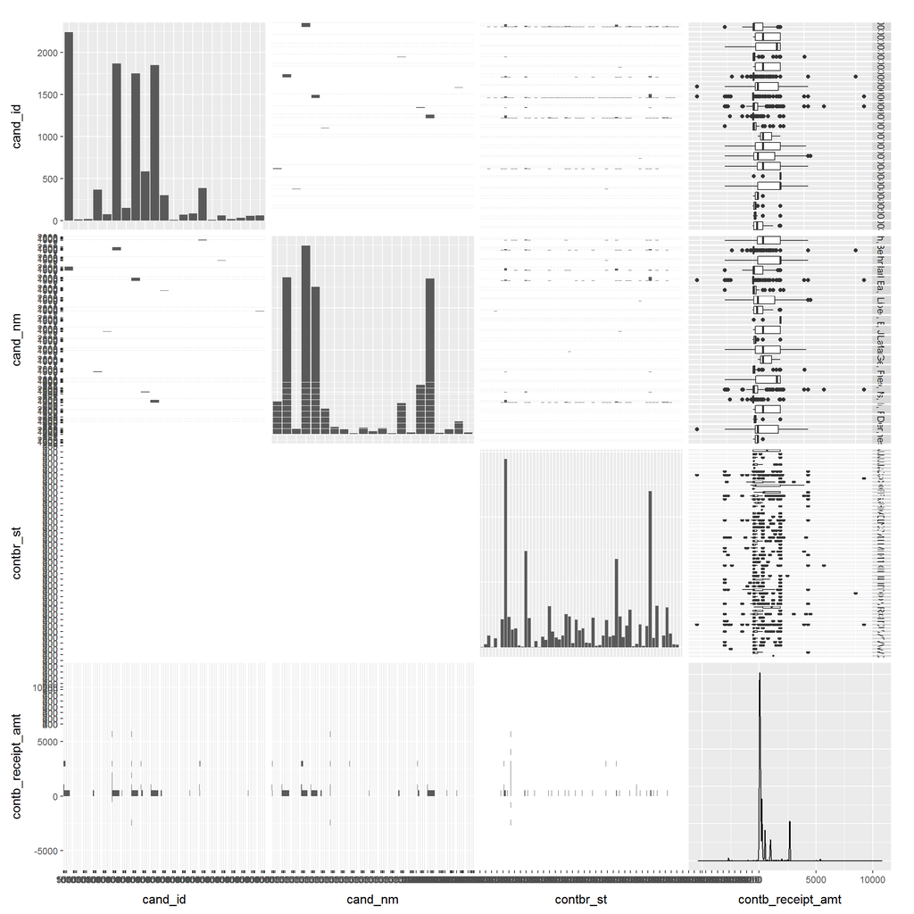

The scatter plot matrix gives us some preliminary plotting of the sampled data set and helps us understand the full data set. The structure, values, shapes of plots, distributions, and preliminary relationships are more understood by plotting each variable against all others. The counts of each variable are plotted on the diagonal. For the off-diagonal plots, the only potentially useful plots are the box plots for the “contb_receipt_amt”, because it is the only quantitative variable.

**Part 1.4. Basic plots: how many counts of itemized contributions and count of each.**

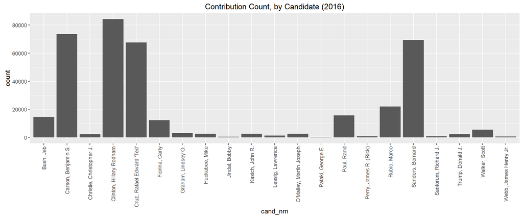

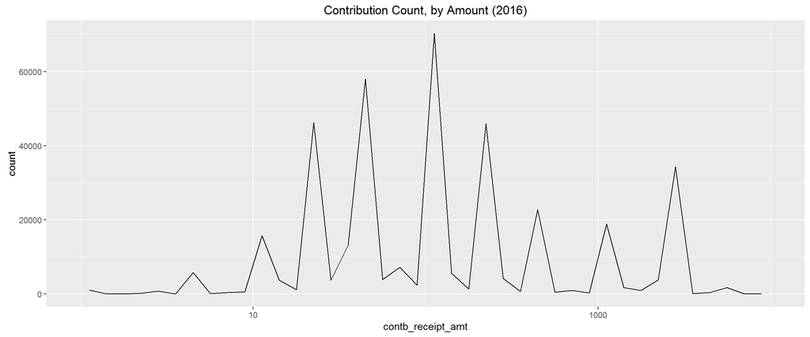

The basic univariate plots show the count of contributions made to each candidate, and the count of all contribution amounts. From the bar graph, Clinton, Sanders, and Carson are the three top contribution count receivers, with upwards of 60,000 contributions. From the line plot, it appears that the distribution of contribution amounts is approximately normal, after transforming the x-axis to logarithmic. Also, the highest contribution counts are for approximately $100 in size.

**Part 1.5. dplyr ops: get total contb receipt amt**  
Create a new data frame to get total “contb_receipt_amt” for each 2016 presidential candidate. The new data frame has the following structure:

```
## Classes 'tbl_df', 'tbl' and 'data.frame':    21 obs. of  3 variables:
##  $ cand_nm  : Factor w/ 21 levels "Bush, Jeb","Carson, Benjamin S.",..: 1 2 3 4 5 6 7 8 9 10 ...
##  $ sum_amnts: num  23243473 11746360 3976329 61726374 17008622 ...
##  $ n        : int  14543 73574 2352 84282 67553 12262 3049 2641 572 2593 ...
```

The total itemized contributions for each candidate are:

```
## prez2016$cand_nm: Bush, Jeb
## [1] 23243473
## --------------------------------------------------------
## prez2016$cand_nm: Carson, Benjamin S.
## [1] 11746360
## --------------------------------------------------------
## prez2016$cand_nm: Christie, Christopher J.
## [1] 3976329
## --------------------------------------------------------
## prez2016$cand_nm: Clinton, Hillary Rodham
## [1] 61726374
## --------------------------------------------------------
## prez2016$cand_nm: Cruz, Rafael Edward 'Ted'
## [1] 17008622
## --------------------------------------------------------
## prez2016$cand_nm: Fiorina, Carly
## [1] 4505707
## --------------------------------------------------------
## prez2016$cand_nm: Graham, Lindsey O.
## [1] 2932403
## --------------------------------------------------------
## prez2016$cand_nm: Huckabee, Mike
## [1] 1895549
## --------------------------------------------------------
## prez2016$cand_nm: Jindal, Bobby
## [1] 1013918
## --------------------------------------------------------
## prez2016$cand_nm: Kasich, John R.
## [1] 3734242
## --------------------------------------------------------
## prez2016$cand_nm: Lessig, Lawrence
## [1] 621494.5
## --------------------------------------------------------
## prez2016$cand_nm: O'Malley, Martin Joseph
## [1] 2921992
## --------------------------------------------------------
## prez2016$cand_nm: Pataki, George E.
## [1] 365091
## --------------------------------------------------------
## prez2016$cand_nm: Paul, Rand
## [1] 4376828
## --------------------------------------------------------
## prez2016$cand_nm: Perry, James R. (Rick)
## [1] 1120363
## --------------------------------------------------------
## prez2016$cand_nm: Rubio, Marco
## [1] 10746283
## --------------------------------------------------------
## prez2016$cand_nm: Sanders, Bernard
## [1] 9018526
## --------------------------------------------------------
## prez2016$cand_nm: Santorum, Richard J.
## [1] 781401
## --------------------------------------------------------
## prez2016$cand_nm: Trump, Donald J.
## [1] 1009731
## --------------------------------------------------------
## prez2016$cand_nm: Walker, Scott
## [1] 4654810
## --------------------------------------------------------
## prez2016$cand_nm: Webb, James Henry Jr.
## [1] 398717.2
```

With the sum for all candidates:

```
## [1] 167798214
```

**Part 1.6. More plots: distributions and sums of itemized contribution amounts**

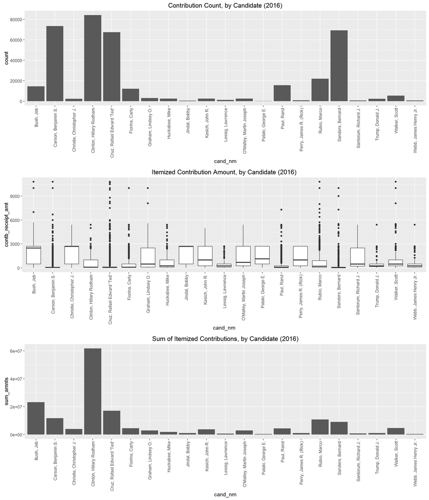

The first bar graph of each candidates total number of contributions is presented along with the box plot of the same candidate and the distribution of the contribution amounts. Additionally, from the data in the recently created data frame shows a bar graph of the total contribution amount each candidate has received.

Focusing on the larger amounts and larger contribution totals, Carson, Clinton, Cruz, and Sanders all have high contribution counts. However, Carson, Cruz, and Sanders have a very similar box plot distribution - they are all near $0 contribution amount (probably more like $100, from the previous line plot). Clinton differs by having higher contribution amounts. Furthermore, Clinton has by far the highest total contribution amount. What is the cause of this discrepancy?

Discrepancy found in the itemized contributions: why so much total dollar contribution for Clinton? Is this reality, or a bug? What is the explanation behind this - especially given the news that Sanders has been setting campaign funding records?

After emailing the FEC [Campaign finance reports and data: pubrec@fec.gov], then calling [phone number 8004249530, option #6], I finally spoke to a FEC data representative who explained this finding. I was able to go to [Ref. 2] for full information on the candidate. Discrepancy was due to the breakdown in itemized/unitemized contributions, and the *.csv datasets that are downloaded from the website are only for itemized contributions. For example, $9MM for Sanders was itemized, but he received more from unitemized - these are the fundraising records that were being broken.

Next, I checked for internal consistency and that was passed. I briefly took the amounts that were reported in the graphic on [Ref. 1] and compared to manually adding the itemized and unitemized amounts from [Ref. 2]. Although I was not able to align perfectly to the single dollar digit, the comparison was much improved with an error of perhaps a few percent. For example, Clinton had $63,366,253.00 from Itemized Individual Contributions from .csv file total [Ref.3], $61,726,374 from ALL.zip .csv via R and used in this analysis [Ref. 1], $62,785,473 from [Ref. 2] summary page - all more or less the same, at least for the purposes of this project’s investigation. Thusly, the understanding is gained for the dataset in the importance of itemized vs. unitemized total amounts for contribution amounts.

**Part 1.7. Add non-itemized contributions as bulk amount**

Manually adding the amounts of unitemized contributions manually to a new data frame, we can then get a better picture for the cash flow coming into each candidate from most campaign sources. New data frame now has unitemized contribution totals from [Ref. 2] included.

**Part 1.8. Sum of Itemized and Unitemized Contributions, by Candidate**

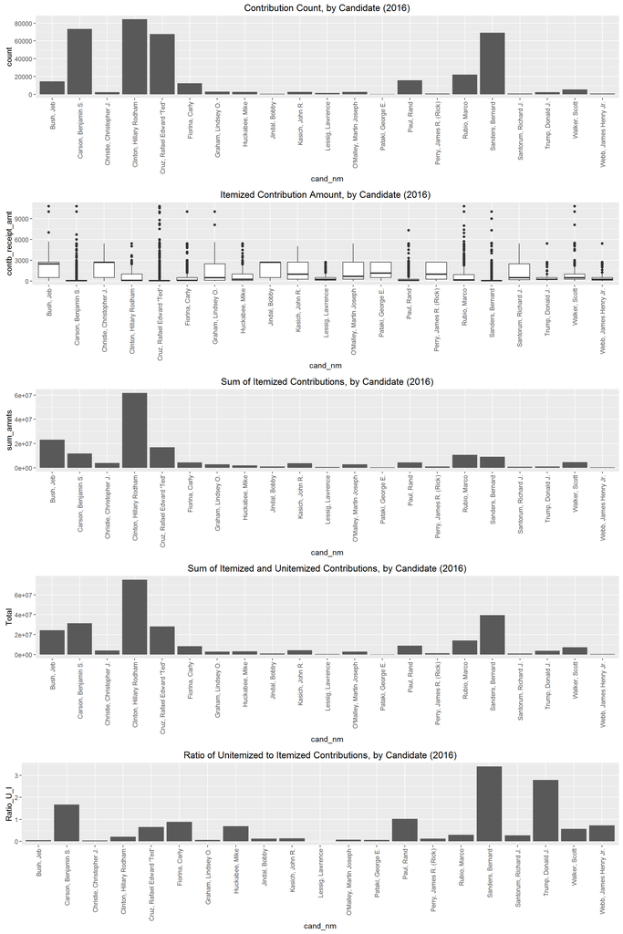

The addition of the unitemized contributions helps paint the full picture of the campaign funds raised by the candidates. The addition of unitemized contributions data makes Sanders a true second place candidate, behind Clinton. Also, taking the ratio of unitemized to itemized contributions, we see that Sanders is the only candidate who has 3 times the unitemized contributions to itemized.

**Part 1.9. Heat map of average itemized contribution amount for each candidate by state**  
A new data frame is made in order to process data in creating a heat map.

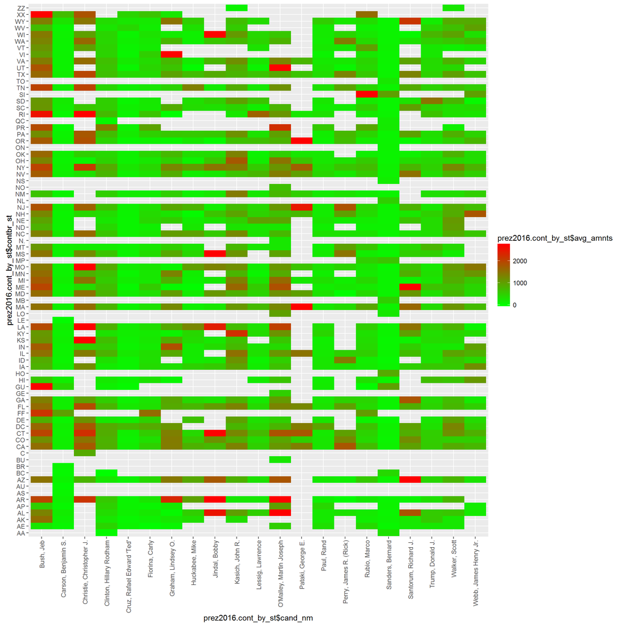

Heat map shows the average contribution amounts by state for each candidate. This can be very useful if we wanted to compare a candidate’s state-averaged contributions to another.

To continue the exploratory data analysis, an investigation on parameter or parameters that can point to who is favored by America, using dollars contributed as their proxy vote, and if it can point to who may win the election.

To approach this we need to replicate above exploratory data analysis on the 2012 and 2008 presidential data [Ref. 1] and see if there are any patterns that emerge.

> > **NOTE** The use of repetitive code below may seem like a function contruct would be more appropriate and efficient, however, I believe that due to the explaratory nature of the analysis and only 2 repeats after the initial, a function is not warranted. Furthermore, the blocks for each year are slightly different and require some modification that a cooking-cutter approach of a function would not permit.

# 2. Exploratory Data Analysis: 2012 Presidential Campaign Finance data set

Purpose of this section is to see patterns with latest available data on a presidential electee, to eliminate inflation and other transient effects from analysis. Note that this is with incumbent president (Obama, assumed office first in 2008).

Basic import of data set, preliminary graphical exploration and investigation.

**Part 2.1. Basic import and explore**

```
## 'data.frame':    6036458 obs. of  18 variables:
##  $ cmte_id          : chr  "C00410118" "C00410118" "C00410118" "C00410118" ...
##  $ cand_id          : Factor w/ 14 levels "P00003608","P20002523",..: 6 6 6 6 6 6 6 6 6 6 ...
##  $ cand_nm          : Factor w/ 14 levels "Bachmann, Michele",..: 1 1 1 1 1 1 1 1 1 1 ...
##  $ contbr_nm        : Factor w/ 1232766 levels "''LEONARD,'', BARBARA MS.",..: 465399 465399 1034544 97445 1160445 69828 97445 97445 209554 207583 ...
##  $ contbr_city      : Factor w/ 24207 levels "","'WESTPORT",..: 13413 13413 10998 16577 9372 20335 16577 16577 13030 21873 ...
##  $ contbr_st        : Factor w/ 95 levels "33","46","48",..: 15 15 15 18 18 18 18 18 20 20 ...
##  $ contbr_zip       : Factor w/ 823594 levels "","*0174","*0177",..: 335956 335956 336906 522825 520719 523923 522825 522825 636051 647499 ...
##  $ contbr_employer  : Factor w/ 430762 levels "","'","'IOLANI SCHOOL",..: 312003 312003 180769 264789 264789 264789 180769 264789 353387 307028 ...
##  $ contbr_occupation: Factor w/ 142663 levels "","'MIS MANAGER",..: 107143 107143 62416 107143 107143 107143 62416 107143 110356 42041 ...
##  $ contb_receipt_amt: num  250 50 250 250 300 500 250 250 250 250 ...
##  $ contb_receipt_dt : Factor w/ 715 levels "01-APR-11","01-APR-12",..: 456 527 104 3 456 527 481 104 481 456 ...
##  $ receipt_desc     : Factor w/ 100 levels "","$67 REFUND ISSUED 5/9/2012; REATTRIBUTION REQUESTED",..: 1 1 1 1 1 1 1 1 1 1 ...
##  $ memo_cd          : Factor w/ 2 levels "","X": 1 1 1 1 1 1 1 1 1 1 ...
##  $ memo_text        : Factor w/ 1285 levels ""," * OVF 2012-CONTRIB. REFUNDED 09/2012",..: 1 1 1 1 1 1 1 1 1 1 ...
##  $ form_tp          : Factor w/ 3 levels "SA17A","SA18",..: 1 1 1 1 1 1 1 1 1 1 ...
##  $ file_num         : int  736166 736166 749073 749073 736166 736166 736166 749073 736166 736166 ...
##  $ tran_id          : Factor w/ 5335680 levels "0000002","0000003",..: 166072 182406 172670 182818 162297 168207 164723 198249 169977 200179 ...
##  $ election_tp      : Factor w/ 10 levels "","G2008","G2012",..: 8 8 8 8 8 8 8 8 8 8 ...
```

Again, results give an indication of the various variable types and the number of unique field values. Most variables are Factor type. For the needs of this analysis, some fields are not necessary and will be carried through in the dataframes but mostly ignored (e.g., “cmte_id”, “tran_id”).

**Part 2.2. Summary**

```
##    cmte_id               cand_id                  cand_nm
##  Length:6036458     P80003338:4117404   Obama, Barack :4117404
##  Class :character   P80003353:1593686   Romney, Mitt  :1593686
##  Mode  :character   P80000748: 151722   Paul, Ron     : 151722
##                     P20002721:  52098   Santorum, Rick:  52098
##                     P60003654:  51795   Gingrich, Newt:  51795
##                     P00003608:  20160   Cain, Herman  :  20160
##                     (Other)  :  49593   (Other)       :  49593
##            contbr_nm              contbr_city        contbr_st
##  SMITH, MICHAEL :    533   NEW YORK     : 138289   CA     : 954661
##  SMITH, DAVID   :    531   CHICAGO      :  85873   NY     : 420359
##  SEBAG, DAVID   :    495   WASHINGTON   :  79944   TX     : 418406
##  JOHNSON, DAVID :    428   LOS ANGELES  :  70450   FL     : 361634
##  SMITH, ROBERT  :    408   HOUSTON      :  65149   IL     : 267657
##  MILLER, MICHAEL:    395   SAN FRANCISCO:  59355   (Other):3613685
##  (Other)        :6033668   (Other)      :5537398   NA's   :     56
##    contbr_zip                                    contbr_employer
##  10025  :   5153   RETIRED                               :1258192
##  20009  :   4182   SELF-EMPLOYED                         : 657312
##  10011  :   3849   NOT EMPLOYED                          : 369056
##  10024  :   3797   INFORMATION REQUESTED PER BEST EFFORTS: 181561
##  10023  :   3337   INFORMATION REQUESTED                 : 137483
##  20008  :   2940   (Other)                               :3430368
##  (Other):6013200   NA's                                  :   2486
##                               contbr_occupation   contb_receipt_amt
##  RETIRED                               :1388962   Min.   :  -60800
##  ATTORNEY                              : 195799   1st Qu.:      25
##  INFORMATION REQUESTED PER BEST EFFORTS: 173593   Median :      50
##  HOMEMAKER                             : 154703   Mean   :     213
##  PHYSICIAN                             : 141315   3rd Qu.:     150
##  (Other)                               :3981555   Max.   :16387179
##  NA's                                  :    531
##   contb_receipt_dt                       receipt_desc     memo_cd
##  17-OCT-12: 179419                             :5968415    :4567779
##  02-NOV-12: 126296   Refund                    :  38867   X:1468679
##  23-OCT-12: 119200   REDESIGNATION TO GENERAL  :   6687
##  31-AUG-12: 106336   REDESIGNATION FROM PRIMARY:   6632
##  22-OCT-12: 100250   REATTRIBUTION TO SPOUSE   :   3303
##  26-OCT-12:  90812   REATTRIBUTION FROM SPOUSE :   3275
##  (Other)  :5314145   (Other)                   :   9279
##                                memo_text        form_tp
##                                     :4546297   SA17A:4553448
##  * OBAMA VICTORY FUND 2012          : 793465   SA18 :1444143
##  TRANSFER FROM ROMNEY VICTORY INC.  : 644731   SB28A:  38867
##  REDESIGNATION TO GENERAL           :   6687
##  REDESIGNATION FROM PRIMARY         :   6632
##  * EARMARKED CONTRIBUTION: SEE BELOW:   6180
##  (Other)                            :  32466
##     file_num             tran_id         election_tp
##  Min.   :723511   SA17.778210:      5   G2012  :3377417
##  1st Qu.:810684   SA17.781520:      5   P2012  :2654178
##  Median :821325   SA17.823900:      5   O2012  :   3229
##  Mean   :831457   SA17.844797:      5          :    722
##  3rd Qu.:842943   SA17.851770:      5   P2008  :    519
##  Max.   :992730   SB28A.100  :      5   G2008  :    248
##                   (Other)    :6036428   (Other):    145
```

Some more insights are obtained about the 2012 financing: Obama has the most contribution counts (4,117,404 counts from “cand_nm”); Michael Smith has donated the most number of times (533 counts from “contbr_nm”); The most donators came from New York City (138,289 counts from “contbr_city”), though the most donators came from California (954,661 counts from “contbr_st”). The most common donator is Retired (1,388,962 counts in “contbr_occupation”). The mean contribution amount is $213, though median is $50 (from “contb_receipt_amt”).

**Part 2.3. Scatterplot Matrix**

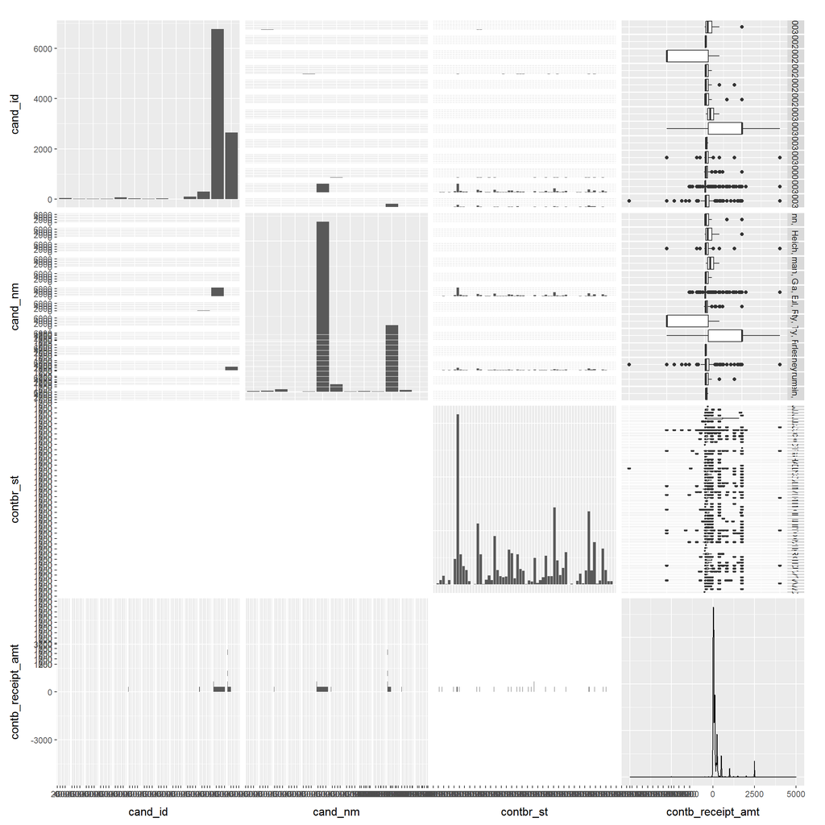

Again, the scatter plot matrix gives us some preliminary plotting of the sampled data set and helps us understand the full data set. The structure, values, shapes of plots, distributions, and preliminary relationships are more understood by plotting each variable against all others. The counts of each variable are plotted on the diagonal. For the off-diagonal plots, the only potentially useful plots are the box plots for the “contb_receipt_amt”, because it is the only quantitative variable.

A detour is needed before proceeding with a comparative analysis to that of the 2016 Presidential data set. The main correction that needs to be applied is the alignment of the same period of time that was used in the 2016 Presidential data set. The solution is to use the same 2012 Presidential data set, but shift in time. Specifically, because the 2016 Presidential data set is from 04/01/2015 to 09/30/2015 [Ref. 2], the same time frame needs to be applied to 2012 Presidential data set - 04/01/2011 to 09/30/2011. Thus, we need to use the receipt date field to convert to a date that R can sort on and then do the analysis on the normalized subset.

**Part 2.4. Basic plots: how many counts of itemized contributions and count of each.**

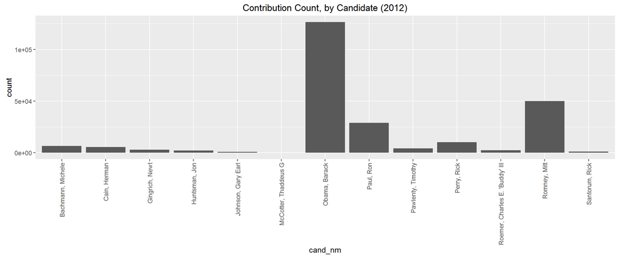

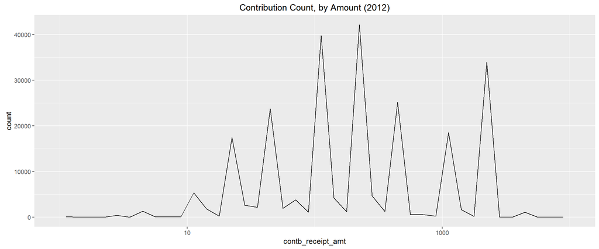

**Part 2.5. dplyr ops: get total contb receipt amt**  
Create a new data frame to get total “contb_receipt_amt” for each 2012 presidential candidate. The new data frame has the following structure:

```
## Classes 'tbl_df', 'tbl' and 'data.frame':    13 obs. of  3 variables:
##  $ cand_nm  : Factor w/ 14 levels "Bachmann, Michele",..: 1 2 3 4 5 6 7 8 9 10 ...
##  $ sum_amnts: num  1836338 1833429 1293623 2047653 616463 ...
##  $ n        : int  6519 5456 2734 2013 862 74 126604 28833 4217 10039 ...
```

The total itemized contributions for each candidate are:

```
## prez2012.normDate$cand_nm: Bachmann, Michele
## [1] 1836338
## --------------------------------------------------------
## prez2012.normDate$cand_nm: Cain, Herman
## [1] 1833429
## --------------------------------------------------------
## prez2012.normDate$cand_nm: Gingrich, Newt
## [1] 1293623
## --------------------------------------------------------
## prez2012.normDate$cand_nm: Huntsman, Jon
## [1] 2047653
## --------------------------------------------------------
## prez2012.normDate$cand_nm: Johnson, Gary Earl
## [1] 616462.8
## --------------------------------------------------------
## prez2012.normDate$cand_nm: McCotter, Thaddeus G
## [1] 37030
## --------------------------------------------------------
## prez2012.normDate$cand_nm: Obama, Barack
## [1] 47752777
## --------------------------------------------------------
## prez2012.normDate$cand_nm: Paul, Ron
## [1] 6103630
## --------------------------------------------------------
## prez2012.normDate$cand_nm: Pawlenty, Timothy
## [1] 3822509
## --------------------------------------------------------
## prez2012.normDate$cand_nm: Perry, Rick
## [1] 16313621
## --------------------------------------------------------
## prez2012.normDate$cand_nm: Roemer, Charles E. 'Buddy' III
## [1] 156441.7
## --------------------------------------------------------
## prez2012.normDate$cand_nm: Romney, Mitt
## [1] 57821077
## --------------------------------------------------------
## prez2012.normDate$cand_nm: Santorum, Rick
## [1] 939509
## --------------------------------------------------------
## prez2012.normDate$cand_nm: Stein, Jill
## [1] NA
```

With the sum for all candidates:

```
## [1] 140574100
```

**Part 2.6. More plots: distributions and sums of itemized contribution amounts**

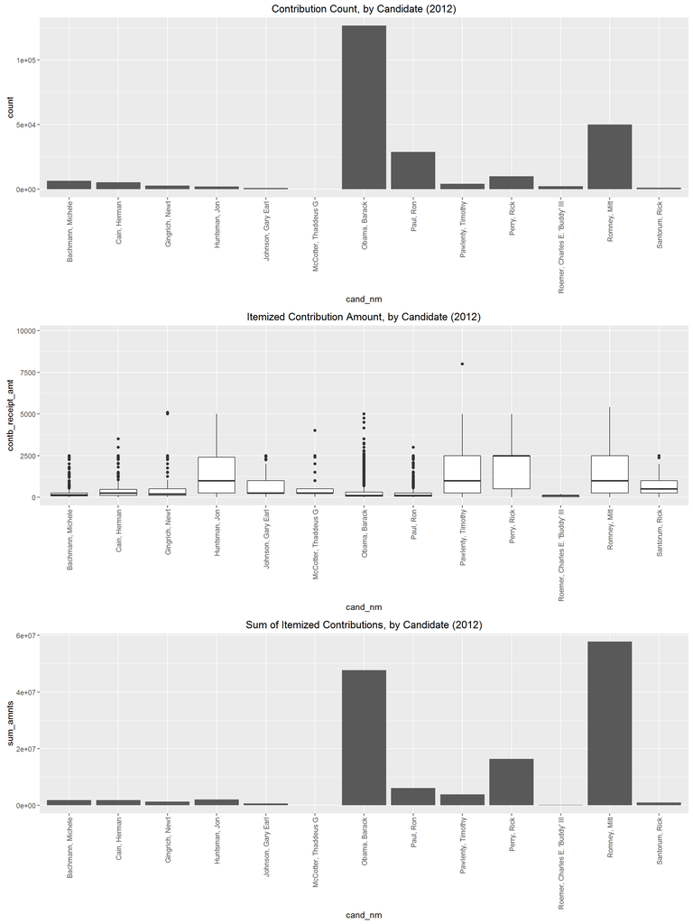

The first bar graph of each candidates total number of contributions is presented along with the box plot of the same candidate and the distribution of the contribution amounts. Additionally, from the data in the recently created data frame shows a bar graph of the total contribution amount each candidate has received.

Focusing on the larger amounts and larger contribution totals, Obama, Romney, and Paul all have high contribution counts. However, Obama and Paul have a very similar box plot distribution - they are all near $0 contribution amount (probably more like $100, from the previous line plot). Romney differs by having higher contribution amounts. Furthermore, Romney has the highest total contribution amount. The discrepancy is again probably due to itemized vs. unitemized contributions, but cannot add non-itemized contributions as bulk amount because unitemized is lumped for the whole 2 year period. Addition of the full 2 year amount could potentially skew results. Therefore, Steps 7 and 8 are skipped.

**Part 2.9. Heat map of average itemized contribution amount for each candidate by state**

A new data frame is made in order to process data in creating a heat map.

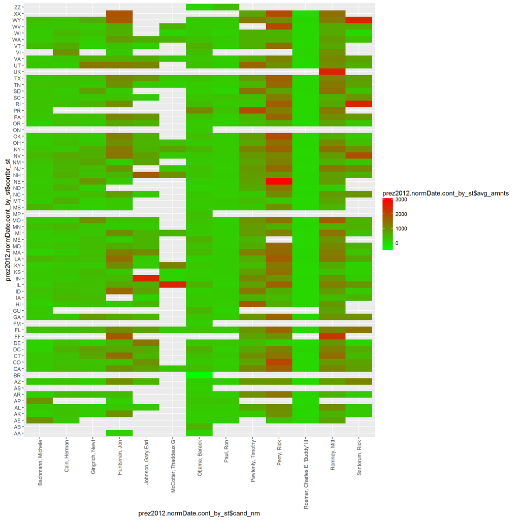

Again, heat map shows the average contribution amounts by state for each candidate. This can be very useful if we wanted to compare a candidate’s state-averaged contributions to another.

Proceeding further in the exploratory data analysis, an investigation on the 2008 presidential campaign finance set is performed. This should eliminate Obama’s incumbency status as a skewing variable in the 2012 data set.

# 3. Exploratory Data Analysis: 2008 Presidential Campaign Finance data set

Purpose of this section is to see patterns with a non-incumbent candidate (2012 was Obama’s incumbency), and compare with the non-incumbent election of 2016.

Basic import of data set, preliminary graphical exploration and investigation.

**Part 3.1. Basic import and explore**

```
## 'data.frame':    4085665 obs. of  18 variables:
##  $ cmte_id          : chr  "C00420224" "C00420224" "C00420224" "C00420224" ...
##  $ cand_id          : Factor w/ 20 levels "P00003186","P00003251",..: 11 11 11 11 11 11 11 11 11 11 ...
##  $ cand_nm          : Factor w/ 20 levels "Biden, Joseph R Jr",..: 4 4 4 4 4 4 4 4 4 4 ...
##  $ contbr_nm        : Factor w/ 1187514 levels "'SULLIVAN, JOHN",..: 129144 557219 188343 285920 1059275 156660 644328 1028248 911655 1091247 ...
##  $ contbr_city      : Factor w/ 23086 levels "","#1","#701",..: 5549 9193 18569 4895 18677 15864 19985 3364 2975 17976 ...
##  $ contbr_st        : Factor w/ 162 levels "-","-1","0","1",..: 12 13 13 13 13 20 20 20 20 28 ...
##  $ contbr_zip       : Factor w/ 892561 levels "","'06002241",..: 891025 376271 229723 377011 375867 663377 671159 665020 669223 745576 ...
##  $ contbr_employer  : Factor w/ 423442 levels "","'","'21' CLUB INC.",..: 1 23852 322377 92233 308227 308227 262133 112177 308227 1 ...
##  $ contbr_occupation: Factor w/ 133849 levels "","'","'A' OPERATOR",..: 117566 103340 111856 121267 1 1 103340 121474 1 103340 ...
##  $ contb_receipt_amt: num  25 25 50 10 25 25 20 5 10 10 ...
##  $ contb_receipt_dt : Factor w/ 994 levels "01-APR-06","01-APR-07",..: 21 784 539 560 560 334 365 334 334 301 ...
##  $ receipt_desc     : Factor w/ 253 levels "","* EARMARKED CONTRIBUTION: SEE BELOW REDESIGNATION",..: 1 1 1 1 1 1 1 1 1 1 ...
##  $ memo_cd          : Factor w/ 2 levels "","X": 1 1 1 1 1 1 1 1 1 1 ...
##  $ memo_text        : Factor w/ 1741 levels "","*","* EARMARKED CONTRIBUTION: SEE BELOW",..: 1 1 1 1 1 1 1 1 1 1 ...
##  $ form_tp          : Factor w/ 3 levels "SA17A","SA18",..: 1 1 1 1 1 1 1 1 1 1 ...
##  $ file_num         : int  288757 288757 305408 288757 288757 288757 288757 288757 288757 288757 ...
##  $ tran_id          : Factor w/ 4013042 levels "0226603-001",..: 3735099 3734881 3735482 3734954 3735009 3734913 3734943 3734932 3734930 3734905 ...
##  $ election_tp      : Factor w/ 13 levels "","2008","G",..: 13 13 13 13 13 13 13 13 13 13 ...
```

Again, results give an indication of the various variable types and the number of unique field values. Most variables are Factor type. For the needs of this analysis, some fields are not necessary and will be carried through in the dataframes but mostly ignored (e.g., “cmte_id”, “tran_id”).

**Part 3.2. Summary**

```
##    cmte_id               cand_id                           cand_nm
##  Length:4085665     P80003338:2600437   Obama, Barack          :2600437
##  Class :character   P00003392: 545162   Clinton, Hillary Rodham: 545162
##  Mode  :character   P80002801: 477267   McCain, John S         : 477267
##                     P80000748:  88574   Paul, Ron              :  88574
##                     P40002347:  85857   Edwards, John          :  85857
##                     P80003353:  83380   Romney, Mitt           :  83380
##                     (Other)  : 204988   (Other)                : 204988
##               contbr_nm              contbr_city        contbr_st
##  PRO, DOODAD       :   1627   NEW YORK     : 163340   CA     : 712532
##  WILL, GOOD        :   1608   CHICAGO      :  84213   NY     : 387672
##  SKINNER, DONNA    :    712   WASHINGTON   :  80381   TX     : 232293
##  VANDERBORGH, CRAIG:    537   LOS ANGELES  :  65696   IL     : 221663
##  ANDERSON, JEFF    :    516   SAN FRANCISCO:  59285   FL     : 208331
##  COSTA, TERRY      :    450   SEATTLE      :  48844   (Other):2312866
##  (Other)           :4080215   (Other)      :3583906   NA's   :  10308
##      contbr_zip           contbr_employer       contbr_occupation
##           :   5640   NOT EMPLOYED : 700763   RETIRED     : 784290
##  00000    :   4809   SELF EMPLOYED: 455908   ATTORNEY    : 230200
##  20743    :   1821   RETIRED      : 184739   NOT EMPLOYED: 122512
##  14517    :   1627                : 173193               : 104024
##  787536608:   1608   SELF-EMPLOYED:  93716   HOMEMAKER   :  91093
##  10025    :   1469   (Other)      :2469661   (Other)     :2749533
##  (Other)  :4068691   NA's         :   7685   NA's        :   4013
##  contb_receipt_amt  contb_receipt_dt
##  Min.   : -43592   30-SEP-08:  90264
##  1st Qu.:     30   16-OCT-08:  76262
##  Median :    100   24-OCT-08:  60821
##  Mean   :    257   31-OCT-08:  55477
##  3rd Qu.:    250   31-JUL-08:  54177
##  Max.   :7250000   30-APR-08:  46556
##                    (Other)  :3702108
##                                 receipt_desc     memo_cd
##                                       :3791464    :3756818
##  REDESIGNATION FROM PRIMARY           :  54452   X: 328847
##  REATTRIBUTION/REDESIGNATION REQUESTED:  49257
##  Refund                               :  47169
##  REDESIGNATION TO                     :  39611
##  REDESIGNATION FROM                   :  39345
##  (Other)                              :  64367
##                                  memo_text        form_tp
##                                       :3547418   SA17A:3758738
##  OVF TRANSFER                         : 194837   SA18 : 279758
##  REDESIGNATION FROM PRIMARY           :  54452   SB28A:  47169
##  REATTRIBUTION/REDESIGNATION REQUESTED:  49257
##  ORIGINAL TRANSACTION                 :  40970
##  REDESIGNATION TO                     :  39611
##  (Other)                              : 159120
##     file_num         tran_id         election_tp
##  Min.   :227197   SB28A.1:     25   P2008  :2713934
##  1st Qu.:360372   SB28A.2:     25   G2008  :1370787
##  Median :753761   SB28A.5:     25          :    816
##  Mean   :607101   SB28A.3:     24   G2006  :     57
##  3rd Qu.:753821   SB28A.4:     24   P      :     54
##  Max.   :877004   SB28A.6:     23   P2007  :      6
##                   (Other):4085519   (Other):     11
```

Some more insights are obtained about the 2008 financing: Obama has the most contribution counts (2,600,437 counts from “cand_nm”); Doodad Pro has donated the most number of times (1627 counts from “contbr_nm”); The most donators came from New York City (163,340 counts from “contbr_city”), though the most donators came from California (712,532 counts from “contbr_st”). The most common donator is Retired (784,290 counts in “contbr_occupation”). The mean contribution amount is $257, though median is $100 (from “contb_receipt_amt”).

**Part 3.3. Scatterplot Matrix**

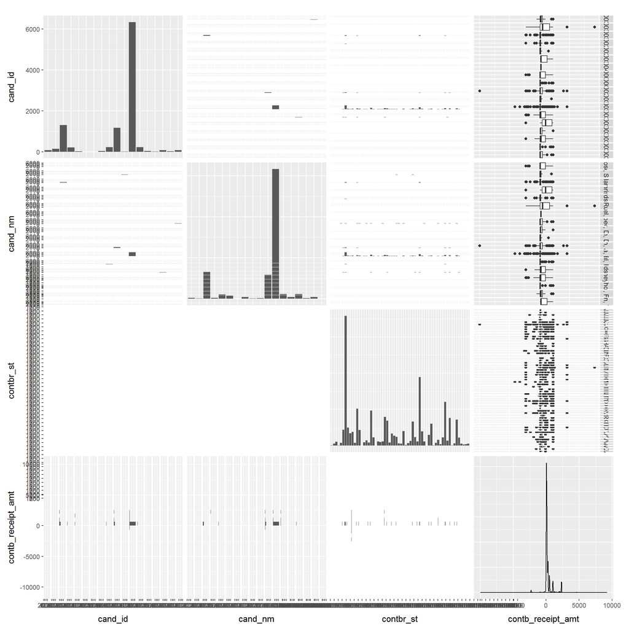

Again, the scatter plot matrix gives us some preliminary plotting of the sampled data set and helps us understand the full data set. The structure, values, shapes of plots, distributions, and preliminary relationships are more understood by plotting each variable against all others. The counts of each variable are plotted on the diagonal. For the off-diagonal plots, the only potentially useful plots are the box plots for the “contb_receipt_amt”, because it is the only quantitative variable.

Again, a detour is needed before proceeding with a comparative analysis to that of the 2016 Presidential data set. The main correction that needs to be applied is the alignment of the same period of time that was used in the 2016 Presidential data set. The solution is to use the same 2008 Presidential data set, but shift in time. Specifically, because the 2016 Presidential data set is from 04/01/2015 to 09/30/2015, the same time frame needs to be applied to 2008 Presidential data set - 04/01/2007 to 09/30/2007. Thus, we need to use the receipt date field to convert to a date that R can sort on and do the analysis on the normalized subset.

**Part 3.4. Basic plots: how many counts of itemized contributions and count of each.**

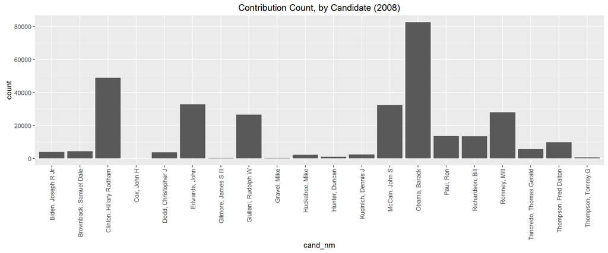

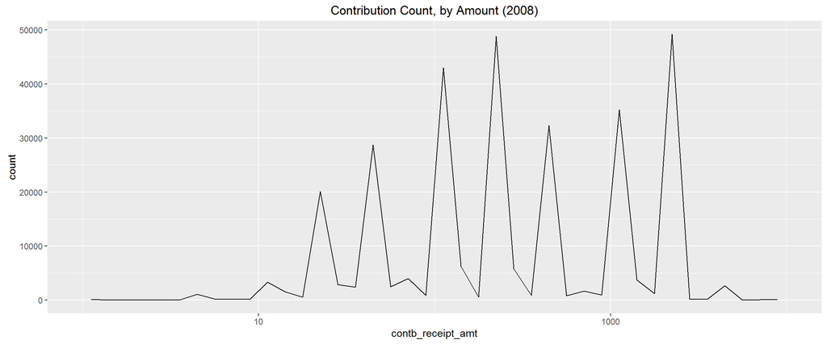

```
## Classes 'tbl_df', 'tbl' and 'data.frame':    20 obs. of  3 variables:
##  $ cand_nm  : Factor w/ 20 levels "Biden, Joseph R Jr",..: 1 2 3 4 5 6 7 8 9 10 ...
##  $ sum_amnts: num  3597035 1130573 45834619 9795 4270934 ...
##  $ n        : int  4005 4387 48943 42 3664 32709 150 26511 271 2295 ...
```

The total itemized contributions for each candidate are:

```
## prez2008.normDate$cand_nm: Biden, Joseph R Jr
## [1] 3597035
## --------------------------------------------------------
## prez2008.normDate$cand_nm: Brownback, Samuel Dale
## [1] 1130573
## --------------------------------------------------------
## prez2008.normDate$cand_nm: Clinton, Hillary Rodham
## [1] 45834619
## --------------------------------------------------------
## prez2008.normDate$cand_nm: Cox, John H
## [1] 9795
## --------------------------------------------------------
## prez2008.normDate$cand_nm: Dodd, Christopher J
## [1] 4270934
## --------------------------------------------------------
## prez2008.normDate$cand_nm: Edwards, John
## [1] 10706162
## --------------------------------------------------------
## prez2008.normDate$cand_nm: Gilmore, James S III
## [1] 175513
## --------------------------------------------------------
## prez2008.normDate$cand_nm: Giuliani, Rudolph W
## [1] 25948989
## --------------------------------------------------------
## prez2008.normDate$cand_nm: Gravel, Mike
## [1] 101379.8
## --------------------------------------------------------
## prez2008.normDate$cand_nm: Huckabee, Mike
## [1] 1297562
## --------------------------------------------------------
## prez2008.normDate$cand_nm: Hunter, Duncan
## [1] 445605.4
## --------------------------------------------------------
## prez2008.normDate$cand_nm: Kucinich, Dennis J
## [1] 661172.1
## --------------------------------------------------------
## prez2008.normDate$cand_nm: McCain, John S
## [1] 14026656
## --------------------------------------------------------
## prez2008.normDate$cand_nm: Obama, Barack
## [1] 40772264
## --------------------------------------------------------
## prez2008.normDate$cand_nm: Paul, Ron
## [1] 4427431
## --------------------------------------------------------
## prez2008.normDate$cand_nm: Richardson, Bill
## [1] 9557015
## --------------------------------------------------------
## prez2008.normDate$cand_nm: Romney, Mitt
## [1] 19139183
## --------------------------------------------------------
## prez2008.normDate$cand_nm: Tancredo, Thomas Gerald
## [1] 775818.2
## --------------------------------------------------------
## prez2008.normDate$cand_nm: Thompson, Fred Dalton
## [1] 8573395
## --------------------------------------------------------
## prez2008.normDate$cand_nm: Thompson, Tommy G
## [1] 543238.5
```

With the sum for all candidates:

```
## [1] 191994338
```

**Part 3.6. More plots: distributions and sums of itemized contribution amounts**

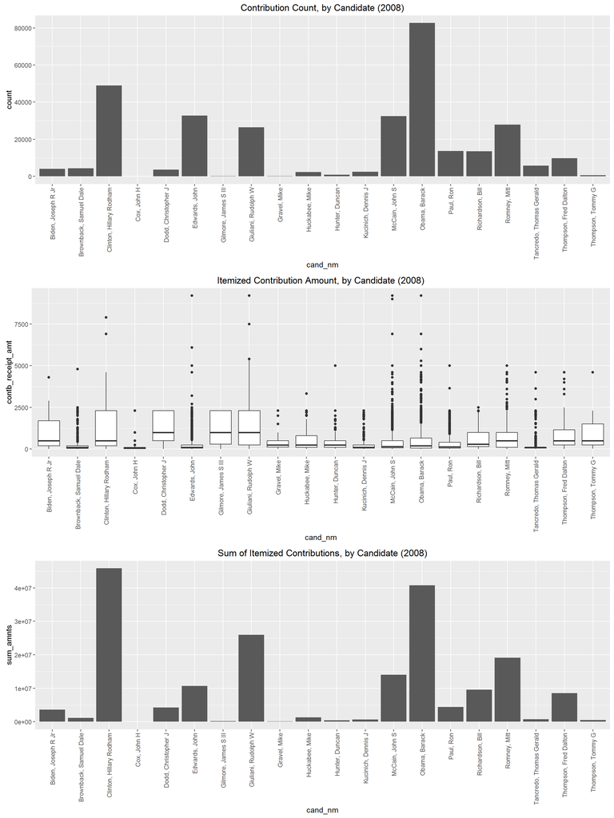

The first bar graph of each candidates total number of contributions is presented along with the box plot of the same candidate and the distribution of the contribution amounts. Additionally, from the data in the recently created data frame shows a bar graph of the total contribution amount each candidate has received.

Focusing on the larger amounts and larger contribution totals, Obama and Clinton all have high contribution counts. However, Obama and Clinton have a very different box plot distribution - Obama’s contributions were all near $0 contribution amount (probably more like $100, from the previous line plot), but Clinton differs by having higher contribution amounts and more spread out distribution. Furthermore, Clinton has the highest total contribution amount. The discrepancy is again probably due to itemized vs. unitemized contributions, but cannot add non-itemized contributions as bulk amount because unitemized is lumped for the whole 2 year period. Addition of the full 2 year amount could potentially skew results. Therefore, Steps 7 and 8 are skipped.

**Part 3.9. Heat map of average itemized contribution amount for each candidate by state**

A new data frame is made in order to process data in creating a heat map.

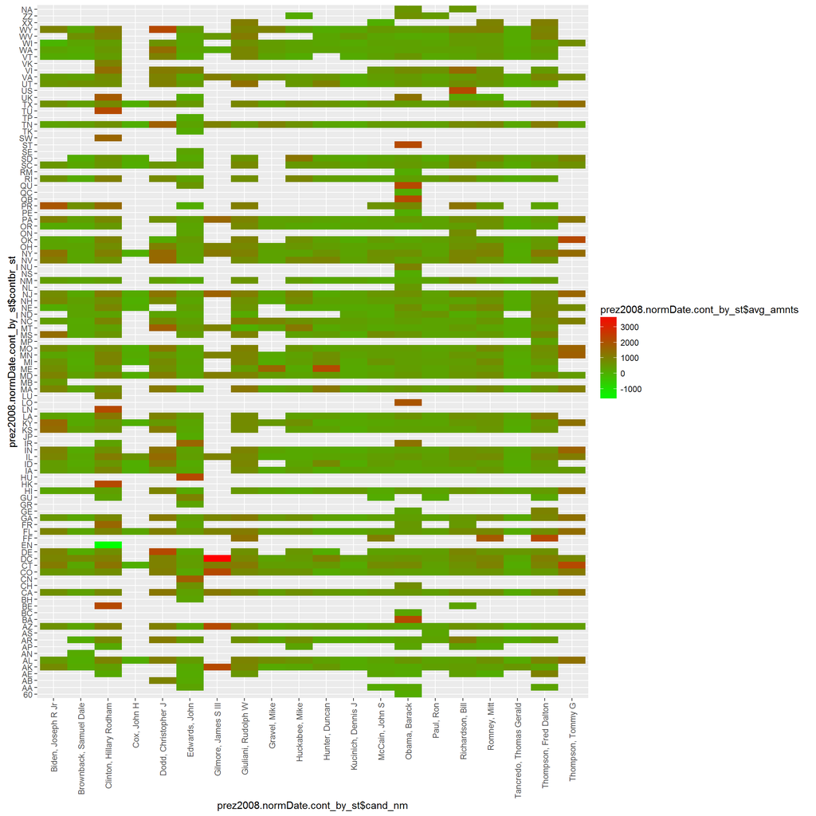

Again, heat map shows the average contribution amounts by state for each candidate. This can be very useful if we wanted to compare a candidate’s state-averaged contributions to another.

At this point, the exploratory data analysis is complete and a rough, high-level understanding of the data and its patterns obtained.

# 4. Univariate Section

## 4.1 Univariate Plots Section

For convenience sake, univariate plots are repeated below from sections 1.4, 2.4, and 3.4 above, and modified as needed to aid with readibility. For example, the line graphs of “contb_receipt_amt” count are combined on one plot to aid in comparison.

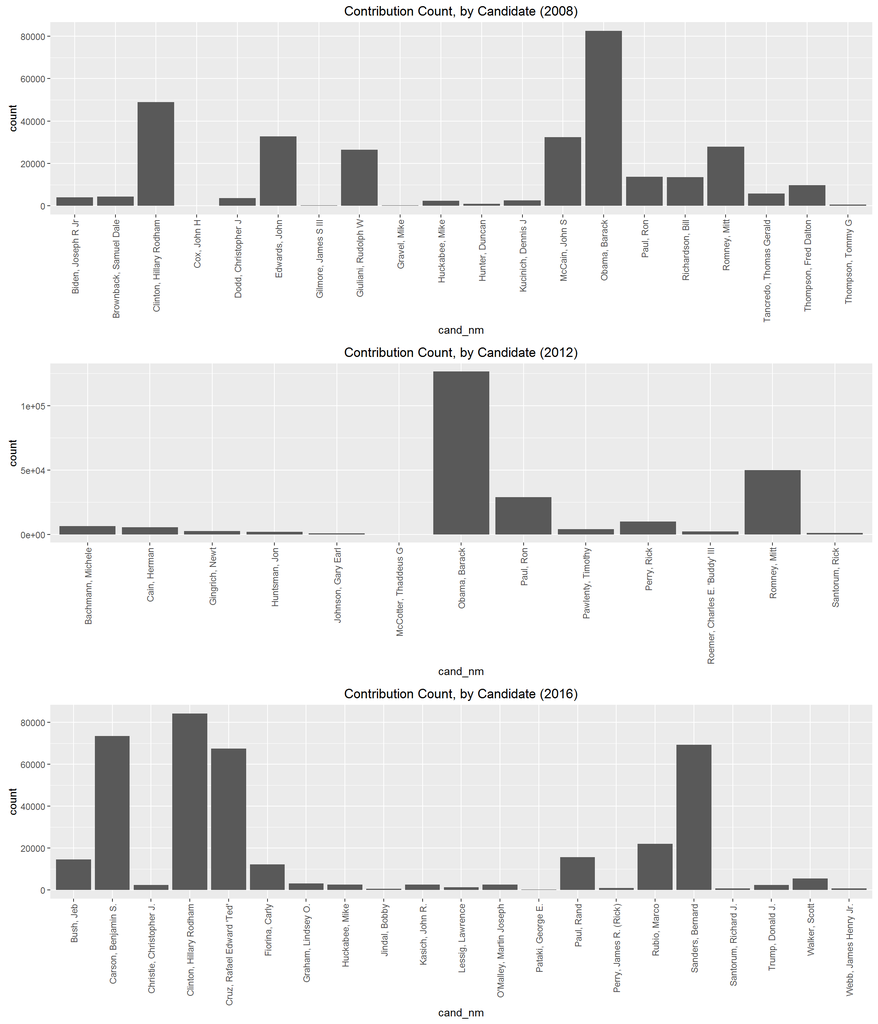

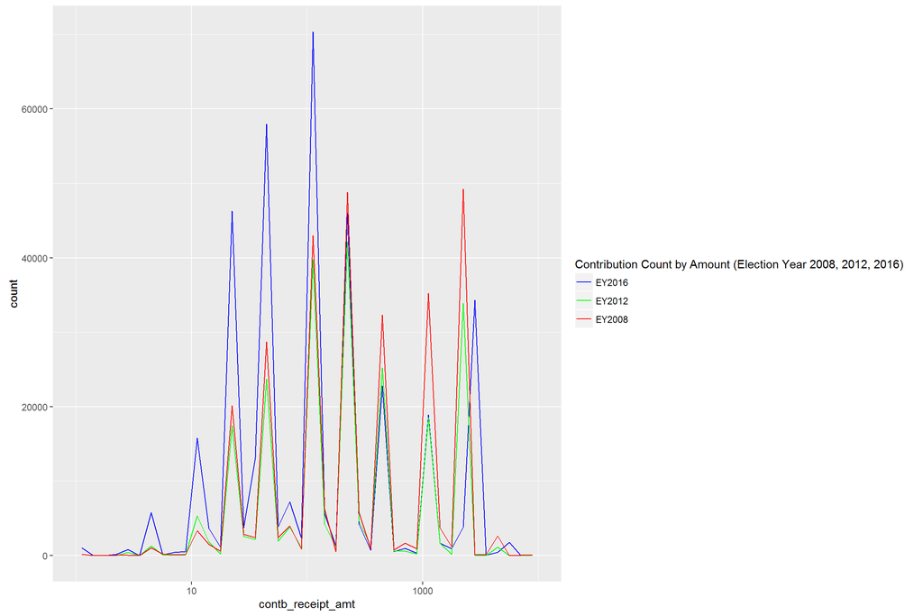

## 4.2 Univariate Analysis

Some observations regarding the dataset are provided, given the questions from the project template.

- What is the structure of your dataset?

The structure of the dataset is provided in Parts 1.1, 2.1, and 3.1 for each 2016, 2012, and 2008 presidential campaign data sets. Generally, the structure contains 18 columns for key fields, and hundreds of thousands of rows, for each contribution received.

- What is/are the main feature(s) of interest in your dataset?

The main features of the datasets are the fields: “cand_nm”, “contbr_st”, and “contb_receipt_amt”.

- What other features in the dataset do you think will help support your investigation into your feature(s) of interest?

Because of the independent nature of the other fields in the dataset, not many other features can be used in support of the features of interest. It is true that some fields like “contbr_city” provide more information and could supplement “contbr_st”, but given the amount of values (11036 different entries for city), the clean up would be great in order to be handled on a laptop’s computing capacity.

- Did you create any new variables from existing variables in the dataset?

Yes, variables that summed and averaged “contb_receipt_amt”, the only numeric field, by state or candidate name were created.

- Of the features you investigated, were there any unusual distributions? Did you perform any operations on the data to tidy, adjust, or change the form of the data? If so, why did you do this?

# 5. Bivariate Section

## 5.1 Bivariate Plots Section

For convenience sake, bivariate plots are repeated below from Parts 1.6, 2.6, and 3.6 above.

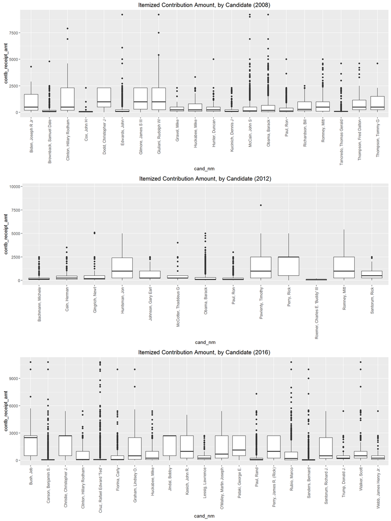

## 5.2 Bivariate Analysis

Some observations regarding the dataset are provided, given the questions from the project template.

- Talk about some of the relationships you observed in this part of the investigation. How did the feature(s) of interest vary with other features in the dataset?

The box plot was the main tool used in comparing two variables, given that only 1 variable in the entire data set was numeric. The relationships and other understanding gained from the dataset from the bivariate plots is discussed in Parts 1.6, 2.6, and 3.6 above.

- Did you observe any interesting relationships between the other features (not the main feature(s) of interest)?

There does appear to be a relationship between the distributions of grass root campaigns (Sanders, Cruz, etc.) and more establishment-supported campaigns (Cristie, Bush, etc.), though not formally quanified. In the grass root campaigns the means, medians, and range of amounts for majority of the contributions are much lower than the establishment campaigns.

- What was the strongest relationship you found?

Unfortunately, because only one numeric variable was provided, no quantitative relationship parameters like Pearson’s r coefficient could be calculated.

# 6. Multivariate Section

## 6.1 Multivariate Plots Section

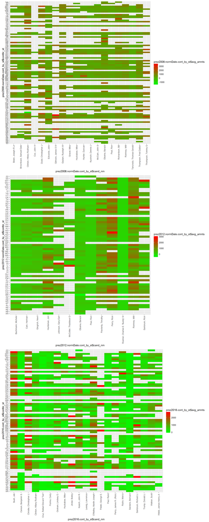

## 6.2 Multivariate Analysis

Some observations regarding the dataset are provided, given the questions from the project template.

- Talk about some of the relationships you observed in this part of the investigation. Were there features that strengthened each other in terms of looking at your feature(s) of interest?

The heat map and scatterplot matrix were the main tools used in comparing 3 variables, given that only 1 variable in the entire data set was numeric (other 2 fields had to be non-numeric, qualitative values). The relationships are first introduced in Parts 1.9, 2.9, and 3.9 above. No further insight is gained because state-level contributions is at a level of granularity that is above the scope of this exploratory data analysis.

- Were there any interesting or surprising interactions between features?

Some interesting, qualitative observations can be obtained. First, there seem to be non-states in the data set, such as “contbr_st”. This could be either a bug, or some proxy for a state or region that needs to be looked into further. The red elements are those states that have contributed to a candidate highly. Likewise, those candidates with non-existant support from majority of states did not get very far in the election process, e.g. John H Cox or Thaddeus McCotter.

- OPTIONAL: Did you create any models with your dataset? Discuss the strengths and limitations of your model.

Unfortunately, because only one numeric variable was provided, it would have been difficult to build a model, at least within the scope of this exploratory data analysis assignment, the tools and concepts available. This is certainly a step in a follow-up analysis of increased rigor.

# 7. Final Plots and Summary

### Plot One

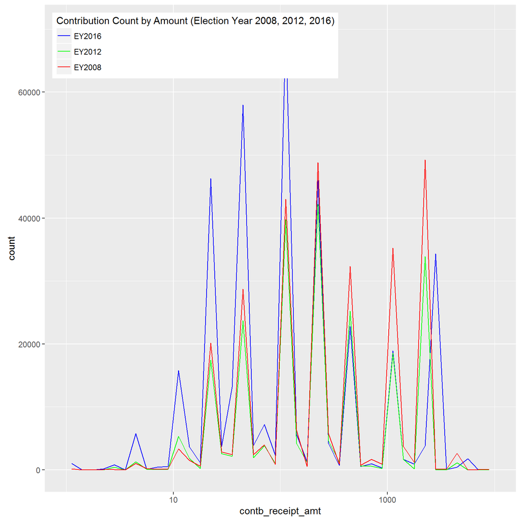

### Description One

The first chosen plot is a univariate comparison of the count of “cont_receipt_amt” by 3 election years. This plot is a first attempt at answering the question “how have contribution amounts varied over the last few election year cycles?”. The general shape is approximately the same approximately normal distribution, with a potential bimodal distribution for EY2008. The counts of large contributions (>$1,000) have decreased from EY2008 to EY2012 and EY2016 from about 50,000 counts to 35,000. Furthermore, only looking at EY2008 and EY2016 - the 2 non-incumbent years - EY2016 spikes at ~$100 contribution amount at 70,000 counts, while EY2008 has two spikes at $200-$500 (50,000 counts) and $2,000-$5,000 (50,000 counts). An interpretation of this decrease in donation amounts from EY2008 to EY2016 is that the average, middle class population is starting to contribute to their candidates of choice, thus voting with their dollars. This is an important note in the face-off in Clinton vs. Sanders for the Democratic ticket - the unitemized contribution funding finding from the section above, combined with the shift in itemized contribution from this plot, and the box plot of contribution amount from the section above - may indicate that the population, generally middle class by people count, is leaning in this direction.

### Plot Two

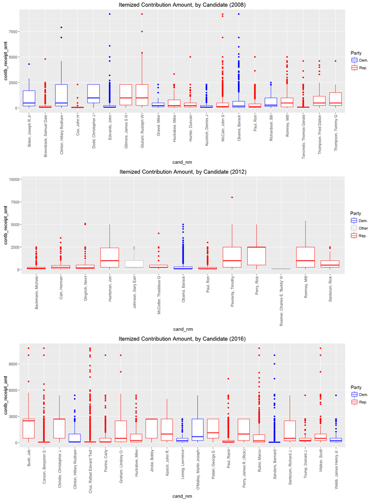

### Description Two

The second chosen plot is a bivariate comparison of the box plots of “cont_receipt_amt” of each candidate by 3 election years (technically this is multivariate with the creation of the party, but this coloring was only meant to aid in elucidating the candidates). This plot is an attempt to show the evolution in time of the winning candidates along with their funding distribution. Tracking Obama starting in 2008 when he first won the election, the distribution is highly skewed towards the smaller values for the median. Clinton, however, is higher in median and significantly higher in the range of the IQR. This behavior is repeated in 2016, with Clinton being the constant. Although her median has dropped to that of Sanders, the quartile range between 75th and 50th remains significantly higher than Sanders, which indicates a presence of wealthy donors. In my opinion, although the absolute amount donated remains important. Even if distribution favors the populist with skew towards the lower contribution amounts is very low total amount, the expectation is that this will not bring the name out and election will probably not happen - a critical mass is needed, with enough money to get the information out to voters across the country. Conversely, if the big money receipient receives massive amounts of money, this lack of concern for resources increases the ability to overwhelm the competition in terms of TV commercials, campaign events, data analysis teams and hardware, logistical support, etc. The takeaway from this plot suggests that Clinton-Sanders resembles a similar pattern to Clinton-Obama, with Sanders appearing on the winning side as Obama did.

### Plot Three

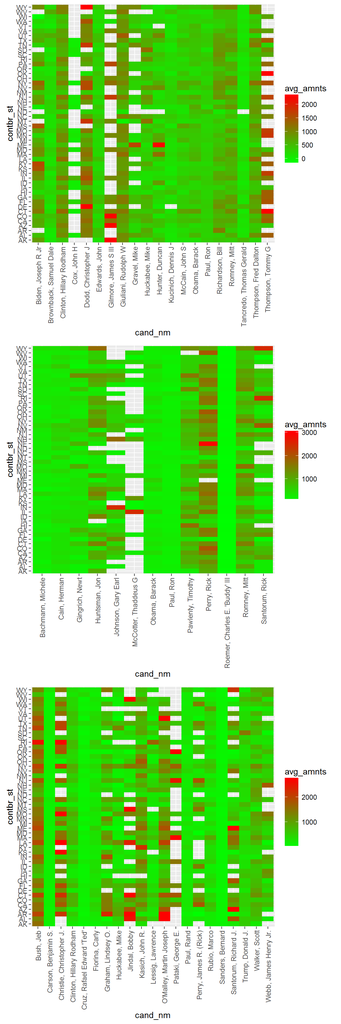

### Description Three

The third chosen plot is a multivariate comparison of the heat maps of “cont_receipt_amt” of each candidate and state by 3 election years. This plot is an attempt to show the evolution in time of the funding distribution mapped amongst the states. Besides a qualitative understanding of each candidate’s state average funding performance and a comparison to their peers, there is not much information to pull from this. The one observation to note is the importance for a candidate to have support amongst all states - low country-wide support probably means no election win.

# 8. Reflection

The successes of this investigation are contained in the exploratory data analysis step that led to many insights. Following the approach of the instructor in the example walk through of exploratory data analysis in Lesson 6 of the course, a similar path was taken here: after obtaining and loading the data, steps were taken to get structure and summary information, scatterplot matrices to see how variables interacted with one another, and then more and more refined univariate, bivariate, and multivariate plots were created to get an understanding of the data.

The difficulties were mostly not so much difficulties, but stepping stones and opportunities to understand R and the exploratory data analysis process better. Some challenges were presented when a certain way the appearance of a plot was desired, but personal attempts were not fruitful; online investigation and consideration of other approaches allowed the solution to be obtain, and sometimes, even other insights were gained about R or the EDA process that were not anticipated or sought after.

The data has potentially revealed that count is an important indicator of potential presidency. For example, in Part 2.6., though Obama has lower median and lower total amount of funding, but he has many more counts than the field and could potentially be used in prediction of the presidency. Furthermore, it appears that the itemized count is an indicator, and unitemized amounts may not be necessary after all. Future work is to build a functional predictive model and see if these insights are correct. Further, it would be ideal if all contribution data, including the unitemized contributions that hindered progress on this investigation, could be included in one set for full analysis.

# Appendix 1. References.

1. http://fec.gov/disclosurep/pnational.do
2. http://fec.gov/fecviewer/CandidateCommitteeDetail.do
3. http://fec.gov/fecviewer/CandCmteTransaction.do
4. Stackoverflow {e.g., [Vertical labeling of x-axis in ggplot](https://stackoverflow.com/questions/1330989/rotating-and-spacing-axis-labels-in-ggplot2); [Changing legend, while combining different graphs based on different data sets on one plot](https://stackoverflow.com/questions/24932940/ggplot-does-not-show-legend-in-geom-histogram); [Conditional data frame modification](https://stackoverflow.com/questions/8005154/conditionally-remove-dataframe-rows-with-r); [Additional data frame variable creation](https://stackoverflow.com/questions/15016723/how-to-add-column-into-a-dataframe-based-on-condition-in-r-programming)}
5. R documentation {via internal ‘?’ and ‘??’ commands}
6. [R Markdown Cheat Sheet](https://www.rstudio.com/wp-content/uploads/2015/02/rmarkdown-cheatsheet.pdf)
7. Miscellaneous {e.g., [Using the underscore in Rmd document without the text after being italicized](https://www.question-defense.com/2010/02/12/include-underscores-while-using-markdown-without-them-being-bold-or-italic-indicators-for-text); }